# BT1101-Tutorial 4 (Part 2 Deadline: 26 Sept 9am)

### Preparation

```r
#install.packages - only need to run this code once to install the package
# load required packages
# library("xxxx")
library("dplyr")
library("tidyr")
library("rpivotTable")
library("knitr")
library("psych")
```

### Tutorial 4 Part 2 (To be submitted - 30 Marks)

- Dataset required: `ds_salaries.csv`

The dataset contains Data Science jobs salary data aggregated by ai-jobs.net. There are 607 observations and 11 variables. Each of the variable (column) is defined as follows:

- `work_year`: The year the salary was paid.
- `experience_level`: The experience level in the job during the year with the following possible values: EN Entry-level / Junior; MI Mid-level / Intermediate; SE Senior-level / Expert; EX Executive-level / Director
- `employment_type`: The type of employment for the role: PT Part-time; FT Full-time; CT Contract; FL Freelance
- `job_title`: The role worked in during the year.
- `salary`: The total gross salary amount paid.
- `salary_currency`: The currency of the salary paid as an ISO 4217 currency code.
- `salary_in_usd`: The salary in USD (FX rate divided by avgerage USD rate for the respective year via fxdata.foorilla.com).
- `employee_residence`: Employee’s primary country of residence during the work year as an ISO 3166 country code.
- `remote_ratio`: The overall amount of work done remotely, possible values are as follows: 0 No remote work (less than 20%); 50 Partially remote; 100 Fully remote (more than 80%)
- `company_location`: The country of the employer’s main office or contracting branch as an ISO 3166 country code.
- `company_size`: The average number of people that worked for the company during the year: S less than 50 employees (small); M 50 to 250 employees (medium); L more than 250 employees (large)

```r
#import dataset into RStudio

DS <- read.csv("ds_salaries.csv")
```

As a business analytics analyst, you are required to perform the following tasks as described in each question below.

### Q2.(a) Descriptive Statistics for `salary_in_usd` (9 marks)

In the previous tutorial, you have examined the frequency distributions of the `salary_in_usd` variable. You would like to learn more about this variable by examining the descriptive statistics. Create a table displaying n (or number of observations), mean, standard deviation, median, skew, and kurtosis. Can you describe the distribution of this variable based on the statistics? (4 marks)

Can you plot a chart and table that provides a visualisation of the mean `salary_in_usd` for different employment types and another chart and table of mean `salary_in_usd` for different experience levels? Describe your observations from these charts? (5 marks)

(For Tutorial discussion: plot a density plot, normal Q-Q plot, and compare these plots with the histogram you have plotted in tutorial 3 as well as the observations you have just made from the descriptive statistics)

**BEGIN: YOUR ANSWER**

```r
##Enter your codes here

# Part 1
dsAmount <- DS %>% summarise(vars='Salary in USD',n=n(),
                             mean=mean(salary_in_usd),
                             sd=sd(salary_in_usd),
                             median=median(salary_in_usd),
                             skew=skew(salary_in_usd),
                             kurtosis=kurtosi(salary_in_usd))
kable(dsAmount, row.names=FALSE, caption = "Description Statistics for Salary in USD")
```

Description Statistics for Salary in USD

| vars | n | mean | sd | median | skew | kurtosis |
| --- | --- | --- | --- | --- | --- | --- |
| Salary in USD | 607 | 112297.9 | 70957.26 | 101570 | 1.659312 | 6.261119 |

```r
# Part 2
## Table and Chart for mean `salary_in_usd` against different employment types

# Create contingency table
meanSalByEmployment <- DS %>% group_by(employment_type) %>% summarise(mean = mean(salary_in_usd)) %>% mutate(across(where(is.numeric), round, 2)) %>% arrange(desc(mean))
kable(meanSalByEmployment, caption = "Mean salary in USD against different employment types")
```

Mean salary in USD against different employment types

| employment_type | mean |
| --- | --- |
| CT | 184575.0 |
| FT | 113468.1 |
| FL | 48000.0 |
| PT | 33070.5 |

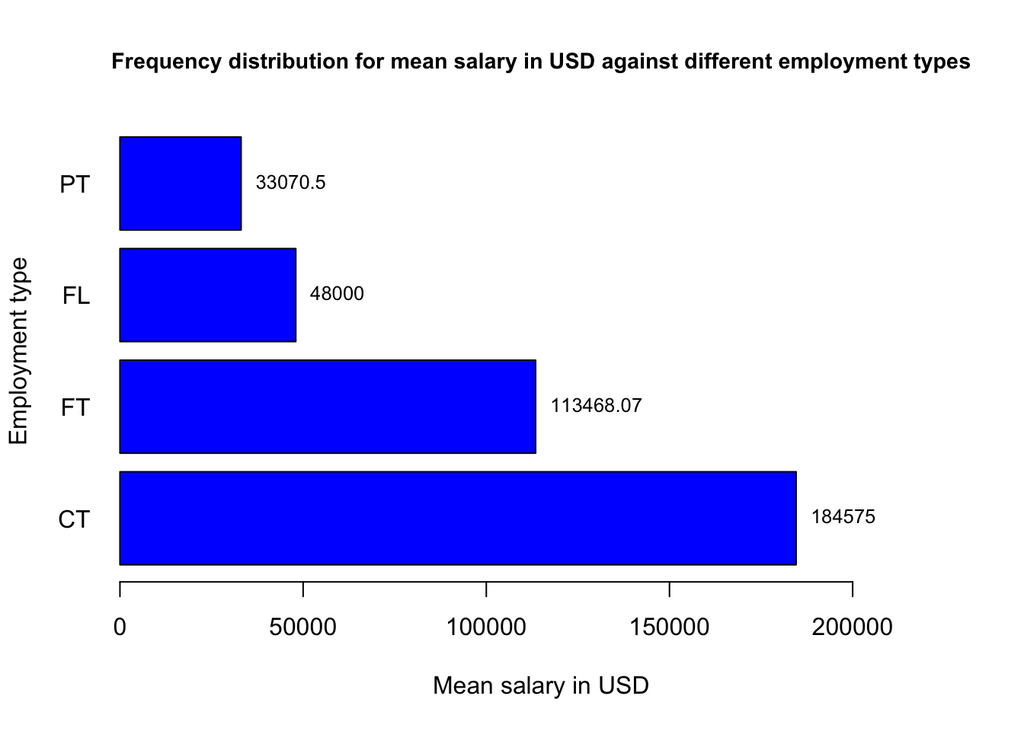

```r
# Create Bar Chart
bpSalEmploy <- barplot(meanSalByEmployment$mean, names.arg = meanSalByEmployment$employment_type,
                 col = "blue",
                 main = "Frequency distribution for mean salary in USD against different employment types",
                 xlab = "Mean salary in USD",
                 horiz = TRUE,
                 xlim = c(0,230000),
                 las = 1,
                 cex.main = 0.9)
mtext("Employment type", side = 2, line = 3, cex.lab = 1, las = 3)
text(x=meanSalByEmployment$mean, y=bpSalEmploy, col="black", meanSalByEmployment$mean, pos=4, cex = 0.8)
```

```r
## Table and Chart for mean `salary_in_usd` for different experience levels
# Create contingency table
meanSalByExp <- DS %>% group_by(experience_level) %>% summarise(mean = mean(salary_in_usd)) %>% mutate(across(where(is.numeric), round, 2)) %>% arrange(desc(mean))
kable(meanSalByExp, caption = "Mean salary in USD for different experience levels")
```

Mean salary in USD for different experience levels

| experience_level | mean |
| --- | --- |
| EX | 199392.04 |
| SE | 138617.29 |
| MI | 87996.06 |
| EN | 61643.32 |

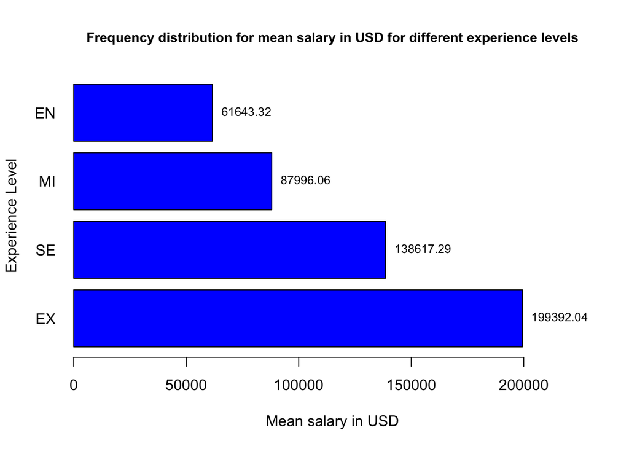

```r
# Create Bar Chart
bpSalExp <- barplot(meanSalByExp$mean, names.arg = meanSalByExp$experience_level,
                 col = "blue",
                 main = "Frequency distribution for mean salary in USD for different experience levels",
                 xlab = "Mean salary in USD",
                 horiz = TRUE,
                 xlim = c(0,230000),
                 las = 1,
                 cex.main = 0.9)
mtext("Experience Level", side = 2, line = 3, cex.lab = 1, las = 3)
text(x=meanSalByExp$mean, y=bpSalExp, col="black", meanSalByExp$mean, pos=4, cex = 0.8)
```

Part 1:  
The standard deviation for Salary in USD is $70957.26. As this number is quite large, it suggests a high degree of variation and dispersion in the data. However, standard deviation is not a normalised measure.  
When looking at the kurtosis, which is the peakedness or flatness of a histogram, the kurtosis coefficient for Salary in USD is 6.261119, which indicates that the data is peaked with less dispersion.  
Next, we can consider the skewness, which describes the lack of symmetry of data. The skewness coefficient for Salary in USD is 1.659312, which indicates a high degree of skewness as it is more than 1. For a positive skewness coefficient, the data is skewed to the right, the tail of the distribution curve is longer on its right side.  
We also see that the mean (112297.9) is greater than the median (101570), which is what we expect from positive skewness.  
Therefore, this data is positively skewed with high kurtosis, showing that it is not a normal distribution.  
Part 2:  
Based on the charts, for Employment Type, CT has the highest mean salary, followed by FT, PL and PT respectively. For Experience Level, EX has the highest mean salary, followed by SE, MI and EN respectively.

**END: YOUR ANSWER**

### Q2.(b) Outlier Analyses for `salary_in_usd` (19 marks)

In the last tutorial, you examined the frequency distributions for employment_type and experience_level. According to industry practice, it is common for salaries to vary across different employment type and experience level. For example, full time employees are usually paid more than part time employees because of the number of hours worked; full-time employment tends to have a different salary structure compared to contract and free-lance work arrangement; higher levels of work experience also confer higher salaries and executive-level directors may be paid more compared to entry or mid-level/intermediate level employees.

- 1. Generate a histogram of `salary_in_usd` for each employment_type. Type what you observe below. (3 marks)
- 2. Given full-time employment is very different from the other employment types, and forms the majority of the data, you have decided to analyse it separately. Keeping only the observations where employment_type is “FT”, plot a histogram of `salary_in_usd` for each experience_level. For each histogram, do a visual inspection to determine whether any outliers exist. Type what you observe below.(4 marks)
- 3. You are told that the `salary_in_usd` variable for full time senior level/ expert roles approximates normal distribution. Could you use the boxplot method to identify if there are any mild or extreme outliers? Type the values of the outliers (if any) below. (5 marks)
- 4. Again, keeping only the data comprising full-time senior level/ expert employment, remove any outliers (even mild ones) if any based on your findings in 2b(iii). Plot the histogram, density plot and normal Q-Q plot for `salary_in_usd` and conduct the Shapiro Wilk’s test on `salary_in_usd`. Explain if `salary_in_usd` for full-time senior level/ expert employment employees is normally distributed. (7 marks)

**BEGIN: YOUR ANSWER**

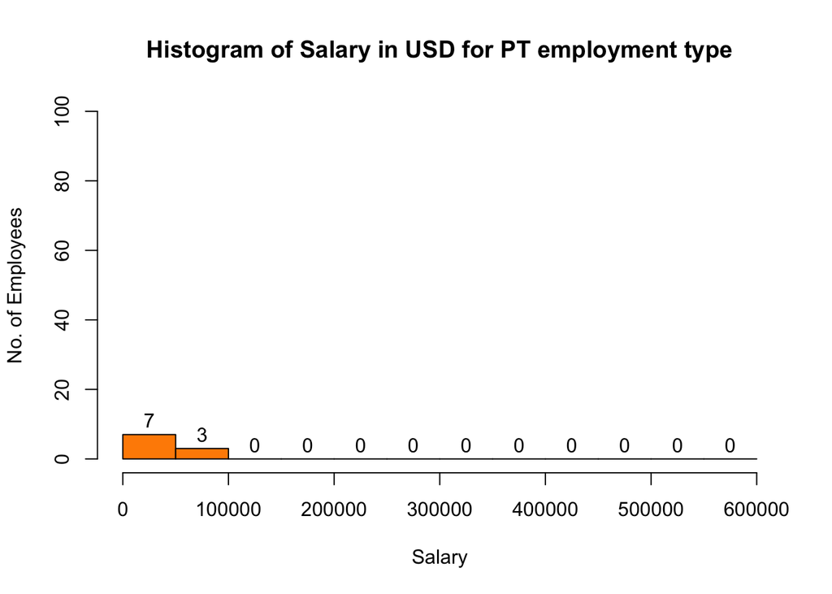

```r
#i)
# Histogram for salary in USD for each employment type()

options(scipen=5) # to remove scientific notation
salaryPT = DS %>% filter(employment_type == "PT") %>% select(salary_in_usd)
histPT<-hist(salaryPT$salary_in_usd,
                 main="Histogram of Salary in USD for PT employment type",
                 xlab="Salary",
                 ylab="No. of Employees",
                 col=c("darkorange"),
                 ylim=c(0,100),
                 breaks = seq(0,600000,length.out = 13),
                 labels=TRUE)
```

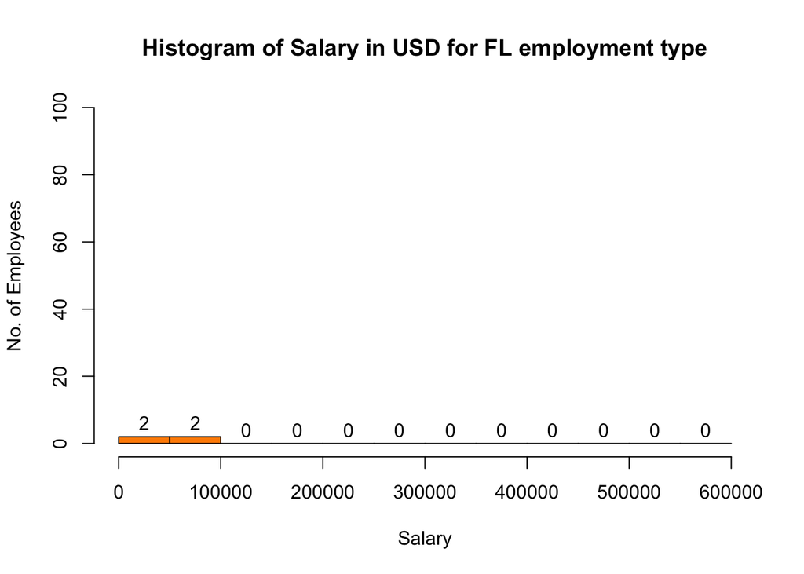

```r
salaryFL = DS %>% filter(employment_type == "FL") %>% select(salary_in_usd)
histFL<-hist(salaryFL$salary_in_usd,
                 main="Histogram of Salary in USD for FL employment type",
                 xlab="Salary",
                 ylab="No. of Employees",
                 col=c("darkorange"),
                 ylim=c(0,100),
                 breaks = seq(0,600000,length.out = 13),
                 labels=TRUE)
```

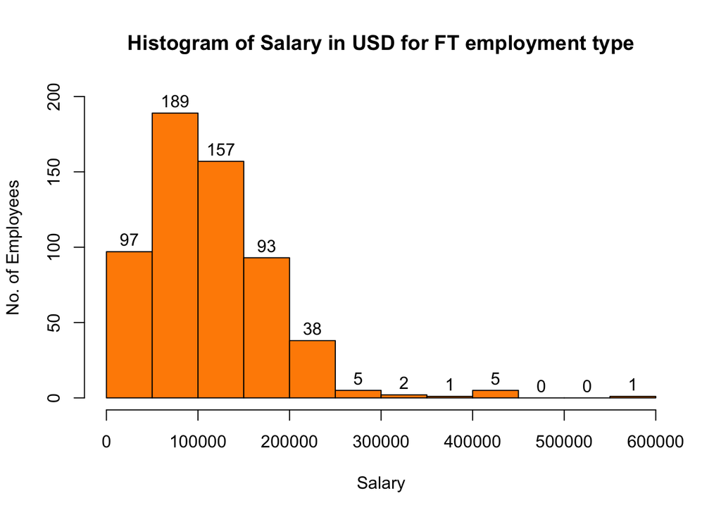

```r
salaryFT = DS %>% filter(employment_type == "FT") %>% select(salary_in_usd)
histFT<-hist(salaryFT$salary_in_usd,
                 main="Histogram of Salary in USD for FT employment type",
                 xlab="Salary",
                 ylab="No. of Employees",
                 col=c("darkorange"),
                 ylim=c(0,200),
                 breaks = seq(0,600000,length.out = 13),
                 labels=TRUE)
```

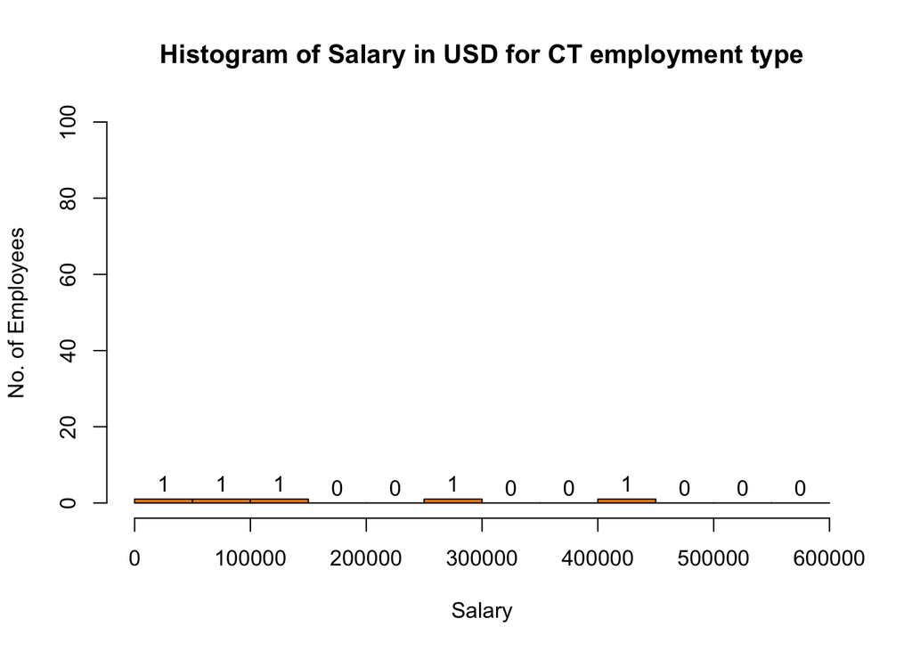

```r
salaryCT = DS %>% filter(employment_type == "CT") %>% select(salary_in_usd)
histCT<-hist(salaryCT$salary_in_usd,
                 main="Histogram of Salary in USD for CT employment type",
                 xlab="Salary",
                 ylab="No. of Employees",
                 col=c("darkorange"),
                 ylim=c(0,100),
                 breaks = seq(0,600000,length.out = 13),
                 labels=TRUE)
```

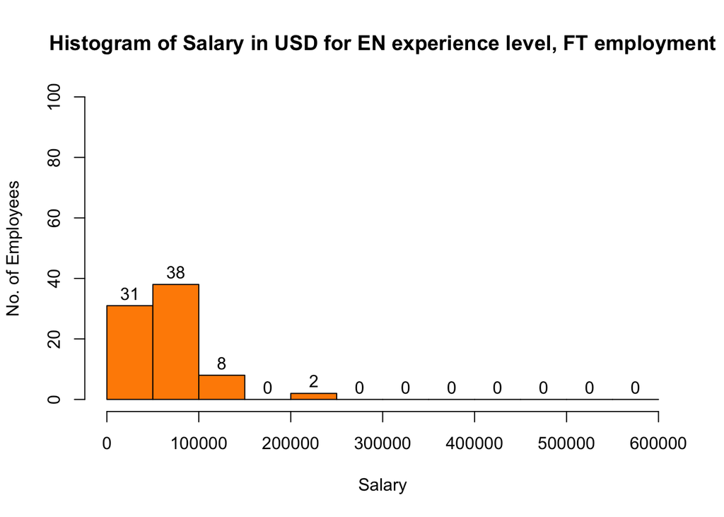

```r
#ii)
# Histogram for salary in USD for each experience type where employment type is FT

salaryENFT = DS %>% filter(experience_level == "EN", employment_type == "FT") %>% select(salary_in_usd)
histENFT<-hist(salaryENFT$salary_in_usd,
                 main="Histogram of Salary in USD for EN experience level, FT employment",
                 xlab="Salary",
                 ylab="No. of Employees",
                 col=c("darkorange"),
                 ylim=c(0,100),
                 breaks = seq(0,600000,length.out = 13),
                 labels=TRUE)
```

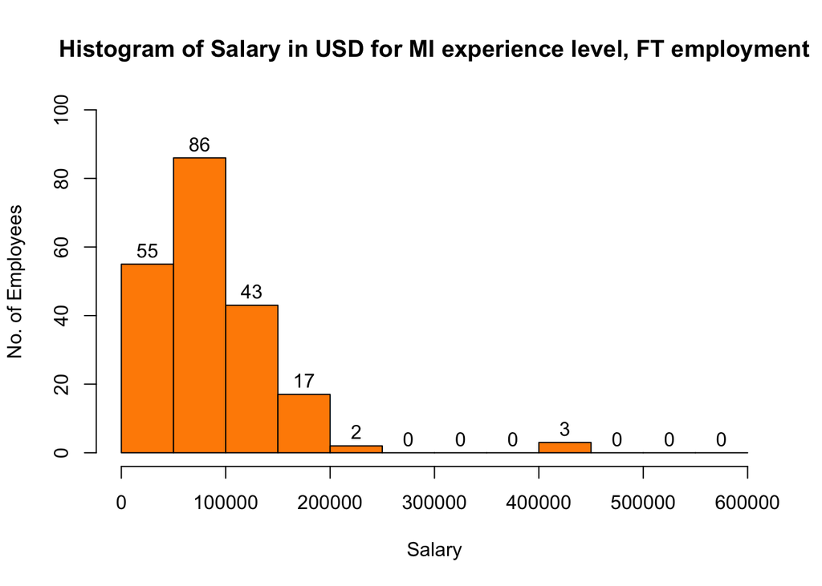

```r
salaryMIFT = DS %>% filter(experience_level == "MI", employment_type == "FT") %>% select(salary_in_usd)
histMIFT<-hist(salaryMIFT$salary_in_usd,
                 main="Histogram of Salary in USD for MI experience level, FT employment",
                 xlab="Salary",
                 ylab="No. of Employees",
                 col=c("darkorange"),
                 ylim=c(0,100),
                 breaks = seq(0,600000,length.out = 13),
                 labels=TRUE)
```

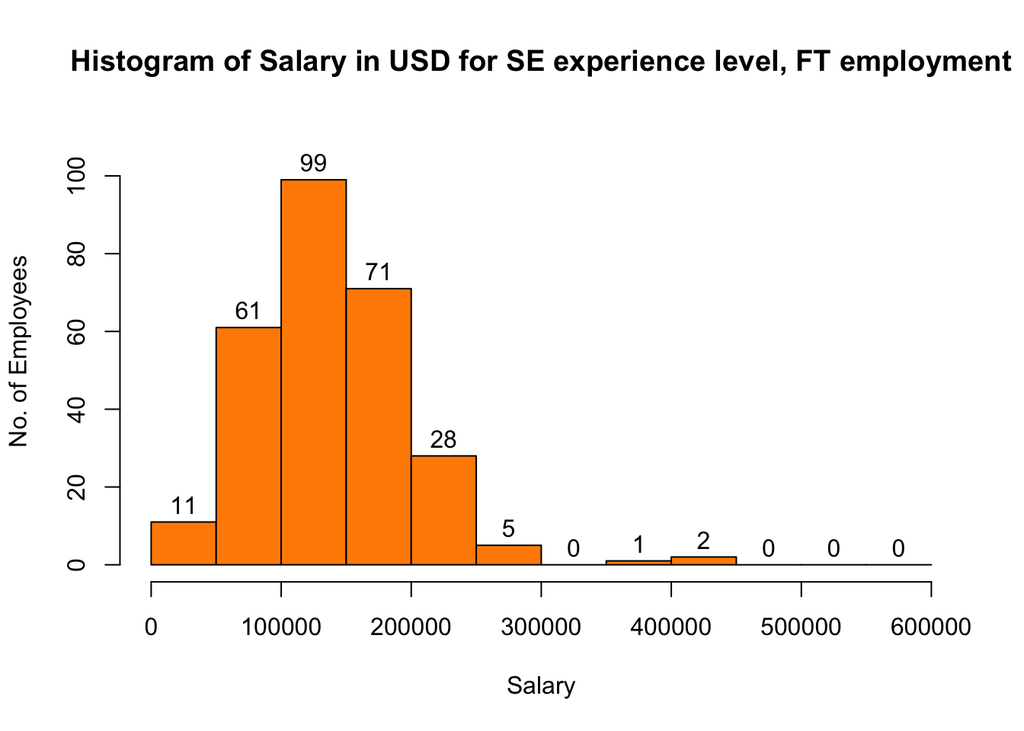

```r
salarySEFT = DS %>% filter(experience_level == "SE", employment_type == "FT") %>% select(salary_in_usd,job_title) # select job title to be used in 2c
histSEFT<-hist(salarySEFT$salary_in_usd,
                 main="Histogram of Salary in USD for SE experience level, FT employment",
                 xlab="Salary",
                 ylab="No. of Employees",
                 col=c("darkorange"),
                 ylim=c(0,110),
                 breaks = seq(0,600000,length.out = 13),
                 labels=TRUE)
```

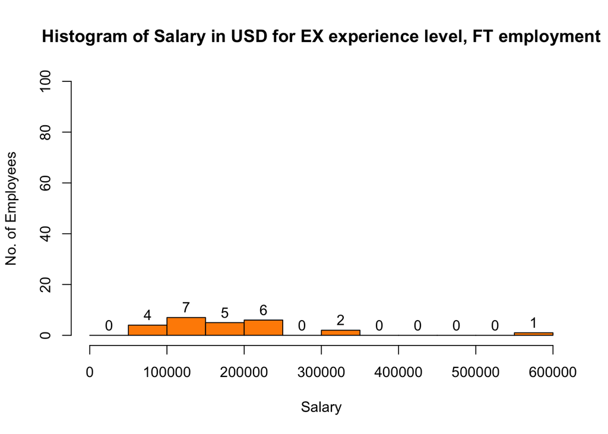

```r
salaryEXFT = DS %>% filter(experience_level == "EX", employment_type == "FT") %>% select(salary_in_usd)
histEXFT<-hist(salaryEXFT$salary_in_usd,
                 main="Histogram of Salary in USD for EX experience level, FT employment",
                 xlab="Salary",
                 ylab="No. of Employees",
                 col=c("darkorange"),
                 ylim=c(0,100),
                 breaks = seq(0,600000,length.out = 13),
                 labels=TRUE)
```

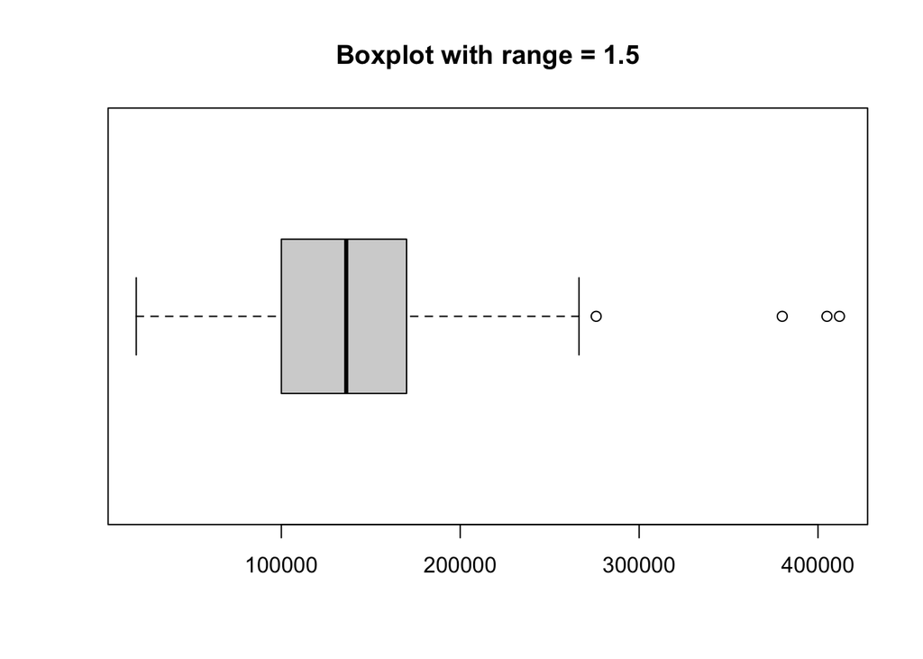

```r
#iii)
# Plot a boxplot for full time SE level, check if any mild or extreme outliers
# For outliers > 1,5IQR
onePointFiveIQROutliers <- boxplot(salarySEFT$salary_in_usd, main='Boxplot with range = 1.5', horizontal =  TRUE)
```

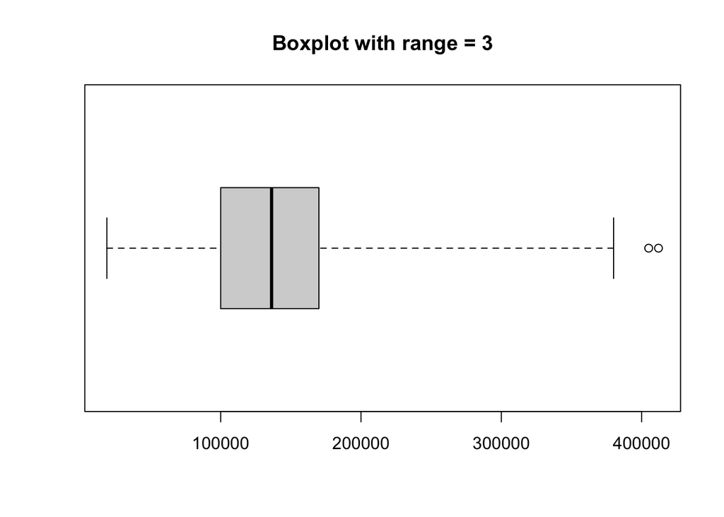

```r
# For outliers > 3IQR
threeIQROutliers <- boxplot(salarySEFT$salary_in_usd, range=3, main='Boxplot with range = 3', horizontal =  TRUE)
```

```r
# Getting the values of outliers
# Getting mild outliers
mildOutliers <- setdiff(onePointFiveIQROutliers$out,threeIQROutliers$out) # setdiff(a,b) identifies values that are in a but not in b
# Getting extreme outliers
extremeOutliers <- threeIQROutliers$out
# Printing out to console mild and extreme outliers
mildOutliers
```

```
## [1] 276000 380000
```

```r
extremeOutliers
```

```
## [1] 412000 405000
```

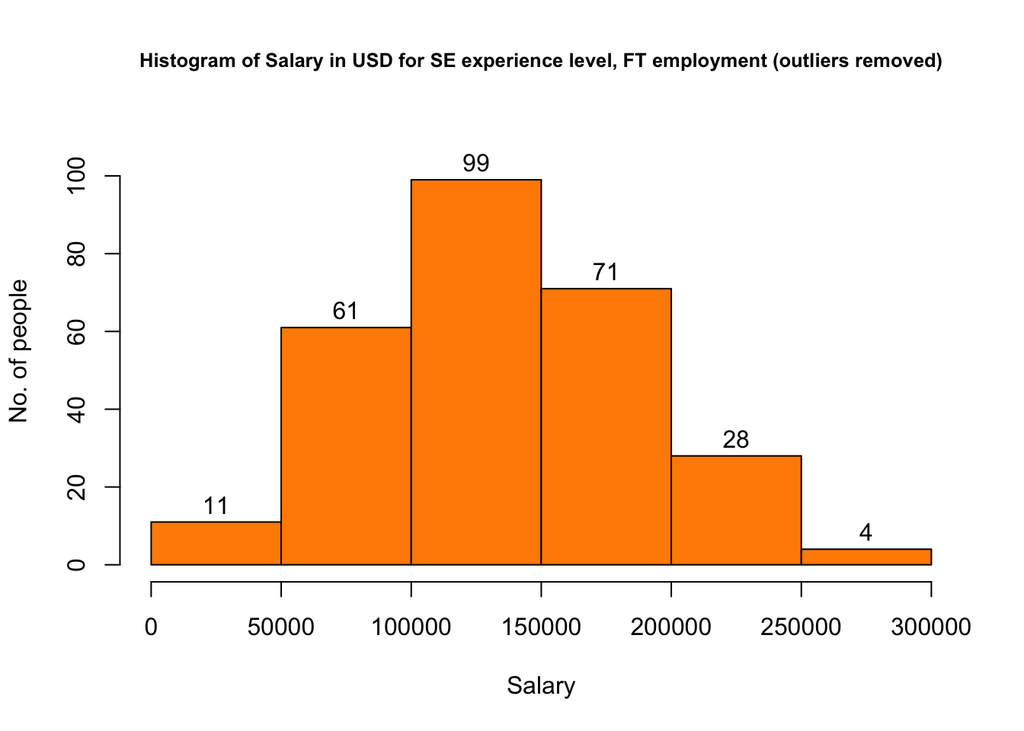

```r
#iv)
# Removing the outliers in salarySEFT
salarySEFT <- salarySEFT %>% filter(salary_in_usd < 276000)

# Plot the histogram, density plot and normal Q-Q plot
SEFT.h<-hist(salarySEFT$salary_in_usd,
                 main="Histogram of Salary in USD for SE experience level, FT employment (outliers removed)",
                 xlab="Salary",
                 ylab="No. of people",
                 col="darkorange",
                 ylim=c(0,110),
                 breaks = seq(0,300000,length.out = 7),
                 cex.main = 0.8,
                 labels=TRUE)
```

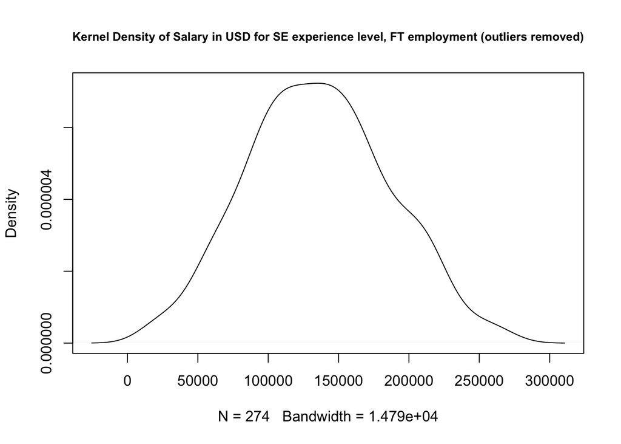

```r
plot(density(salarySEFT$salary_in_usd), main = "Kernel Density of Salary in USD for SE experience level, FT employment (outliers removed)", cex.main = 0.8)
```

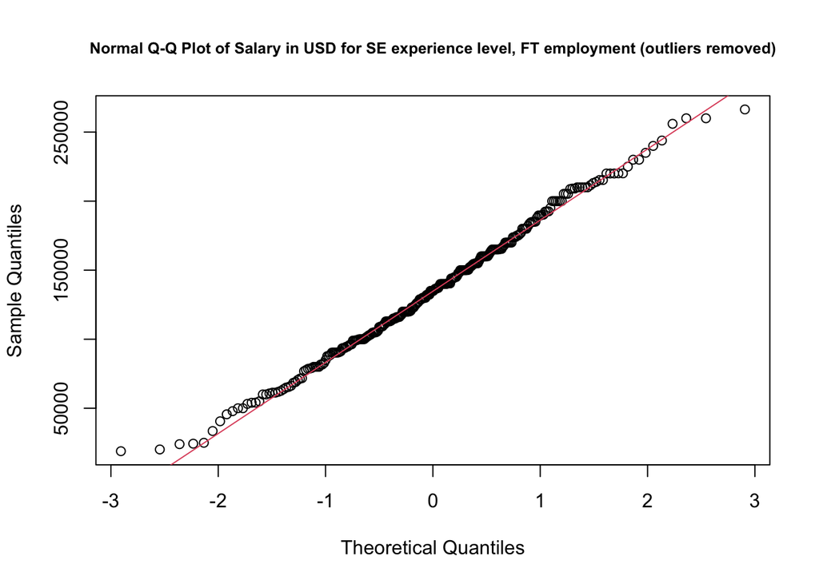

```r
qqnorm(salarySEFT$salary_in_usd, main = "Normal Q-Q Plot of Salary in USD for SE experience level, FT employment (outliers removed)", cex.main = 0.8)
qqline(salarySEFT$salary_in_usd, col=2) # 2 is red
```

```r
# Conduct the Shapiro Wilk's test on `salary_in_usd`
shapiro.test(salarySEFT$salary_in_usd)
```

```
##
##  Shapiro-Wilk normality test
##
## data:  salarySEFT$salary_in_usd
## W = 0.99411, p-value = 0.3654
```

**END: YOUR ANSWER**

### Q2.(c) Computing proportions and probabilities (2 marks)

- 1. Using the data from 2b(iv), compute the proportion of full time senior level/expert employees who are Data Scientist. (1 mark)
- 2. Given that `salary_in_usd` is a random variable that is normally distributed with mean of 135600 and standard deviation of 50500, what is the probability of `salary_in_usd` being less than $110,000. (1 mark)

**BEGIN: YOUR ANSWER**

```r
#i)
dataScientistSEFT <- salarySEFT %>% filter(job_title == "Data Scientist")
nrow(dataScientistSEFT)/nrow(salarySEFT)
```

```
## [1] 0.2189781
```

```r
#ii)
pnorm(110000,mean=135600,sd=50500,lower.tail = TRUE)
```

```
## [1] 0.3061017
```

Part i) After removal of outliers, proportion of full time senior level/expert employees who are Data Scientist is 0.2189781.  
Part ii) Probability of `salary_in_usd` being less than $110,000 is 0.3061017.

**END: YOUR ANSWER**